# GSE143893

ukke

6 december 2021

```r
library(affy)
library(arrayQualityMetrics)
library(ArrayExpress)
library(limma)
library(siggenes)
```

# Methylation Data

We selected the dataset with accession number GSE143893 as a methylation dataset. This data contains Whole Genome Bisulfite Sequencing of CD4+ T cells from mice developmentally exposed to vehicle or TCDD prior to and during influenza infection. We loaded only samples from mice that were not treated with TCDD.

## General info

Methylation profiling by high throughput sequencing:GSE143893 We selected the dataset with accession number GSE143893 as a methylation dataset. This data contains Whole Genome Bisulfite Sequencing of CD4+ T cells from mice developmentally exposed to vehicle or TCDD prior to and during influenza infection. We loaded only samples from mice that were not treated with TCDD.

## Intensity values

loading in the data

```r
library(methylKit)
file.list=list( "C:/Users/tobia/Documents/AHAT/GSM4276332_Vehicle-Naive1_CpG.txt",
                "C:/Users/tobia/Documents/AHAT/GSM4276334_Vehicle-Naive2_CpG.txt",
                "C:/Users/tobia/Documents/AHAT/GSM4276336_Vehicle-Naive3_CpG.txt",
                "C:/Users/tobia/Documents/AHAT/GSM4276338_Vehicle-Infected1_CpG.txt",
                "C:/Users/tobia/Documents/AHAT/GSM4276340_Vehicle-Infected2_CpG.txt",
                "C:/Users/tobia/Documents/AHAT/GSM4276342_Vehicle-Infected3_CpG.txt")
# read the files to a methylRawList object: myobj immediately filter so that sites supported by less than 10 are not used
myobj=methRead(file.list,
           sample.id=list("vehicle_naive1","vehicle_naive2", "vehicle_naive3","vehicle_infected1","vehicle_infected2", "vehicle_infected3"),
           assembly="GRCm38.p5",
           treatment=c(0,0,0,1,1,1),
           context="CpG",
           mincov = 10
           )
```

```
## Received list of locations.
```

```
## Reading file.
## Reading file.
## Reading file.
## Reading file.
## Reading file.
## Reading file.
```

```r
head(myobj)
```

```
## [[1]]
## methylRaw object with 3313657 rows
## --------------
##    chr   start     end strand coverage numCs numTs
## 1 chr1 3003380 3003380      -       10     9     1
## 2 chr1 3009138 3009138      -       10     9     1
## 3 chr1 3011266 3011266      -       12    11     1
## 4 chr1 3012097 3012097      -       11    11     0
## 5 chr1 3014974 3014974      +       12    12     0
## 6 chr1 3017888 3017888      -       13     9     4
## --------------
## sample.id: vehicle_naive1
## assembly: GRCm38.p5
## context: CpG
## resolution: base
##
##
## [[2]]
## methylRaw object with 2388205 rows
## --------------
##    chr   start     end strand coverage numCs numTs
## 1 chr1 3003583 3003583      -       10    10     0
## 2 chr1 3005999 3005999      -       11     8     3
## 3 chr1 3007581 3007581      -       13    11     2
## 4 chr1 3012097 3012097      -       11    11     0
## 5 chr1 3014612 3014612      -       12    12     0
## 6 chr1 3017888 3017888      -       12     6     6
## --------------
## sample.id: vehicle_naive2
## assembly: GRCm38.p5
## context: CpG
## resolution: base
##
##
## [[3]]
## methylRaw object with 3445871 rows
## --------------
##    chr   start     end strand coverage numCs numTs
## 1 chr1 3007581 3007581      -       13    11     2
## 2 chr1 3009138 3009138      -       11    10     1
```

[output cut: 45 more lines]

```
## [[6]]
## methylRaw object with 4769378 rows
## --------------
##    chr   start     end strand coverage numCs numTs
## 1 chr1 3011266 3011266      -       13    12     1
## 2 chr1 3011314 3011314      -       12    10     2
## 3 chr1 3012097 3012097      -       10    10     0
## 4 chr1 3014533 3014533      -       12    12     0
## 5 chr1 3014556 3014556      -       16    16     0
## 6 chr1 3014612 3014612      -       16    15     1
## --------------
## sample.id: vehicle_infected3
## assembly: GRCm38.p5
## context: CpG
## resolution: base
```

### viewing the data

View the methylation rates per sample with the plot function that is provided in the package.

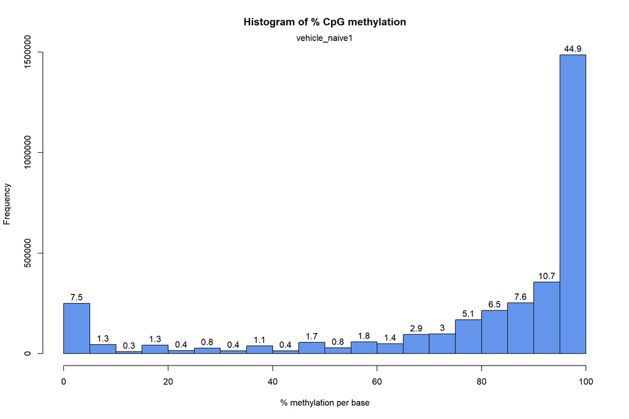

```r
naive_1 <- getMethylationStats(myobj[[1]],plot=TRUE,both.strands=FALSE)
```

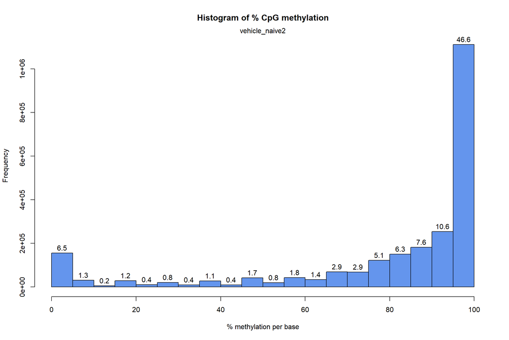

```r
naive_2 <- getMethylationStats(myobj[[2]],plot=TRUE,both.strands=FALSE)
```

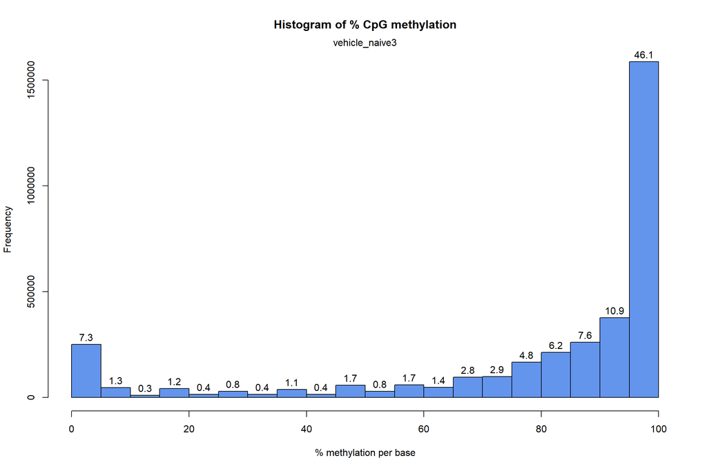

```r
naive_3 <- getMethylationStats(myobj[[3]],plot=TRUE,both.strands=FALSE)
```

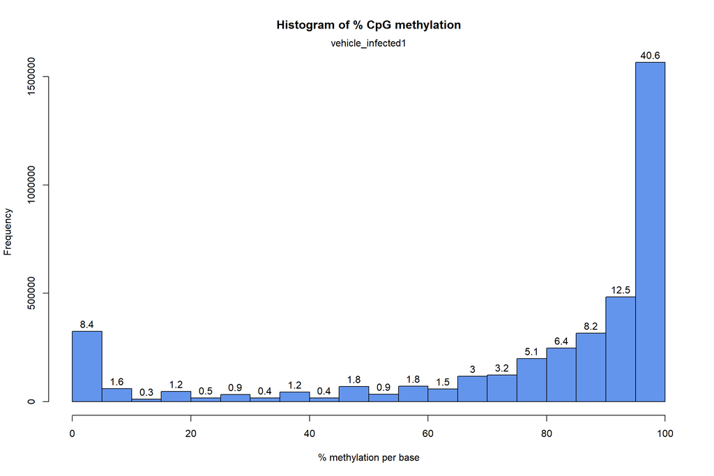

```r
infected_1 <- getMethylationStats(myobj[[4]],plot=TRUE,both.strands=FALSE)
```

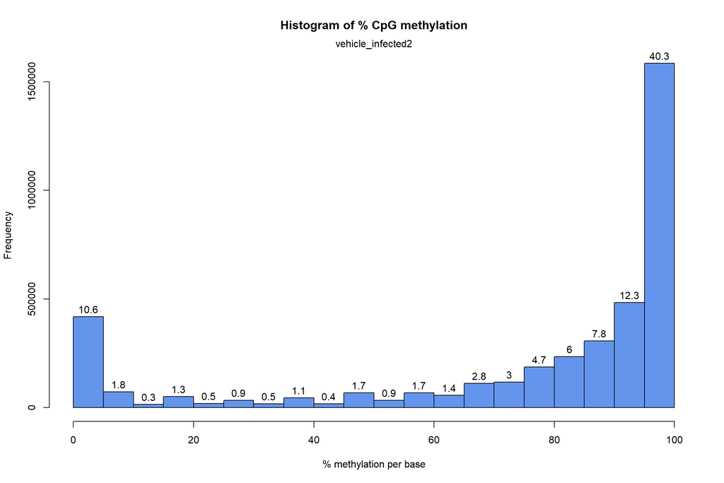

```r
infected_2 <- getMethylationStats(myobj[[5]],plot=TRUE,both.strands=FALSE)
```

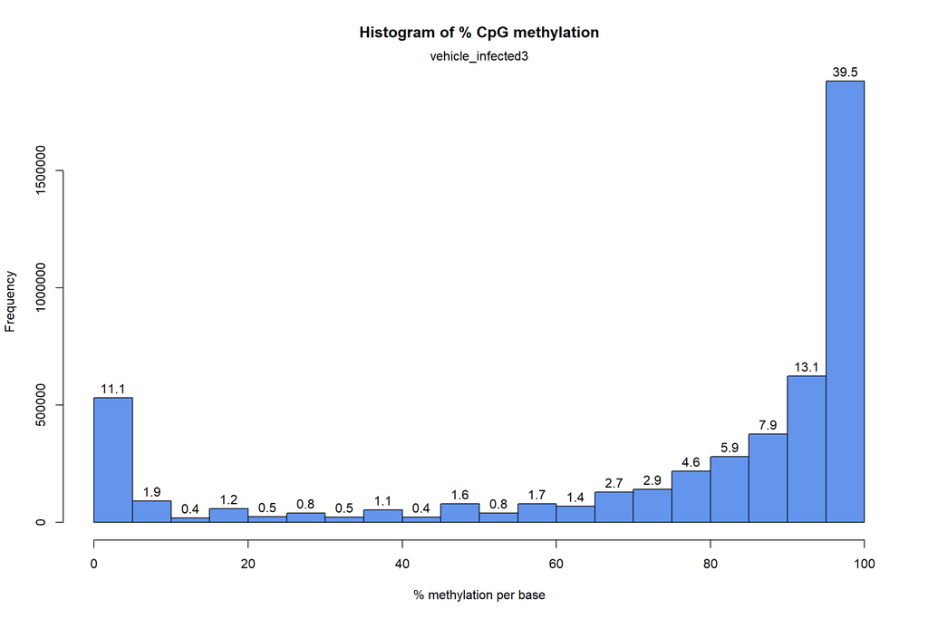

```r
infected_3 <- getMethylationStats(myobj[[6]],plot=TRUE,both.strands=FALSE)
```

View the coverage rates per sample with the plot function that is provided in the package.

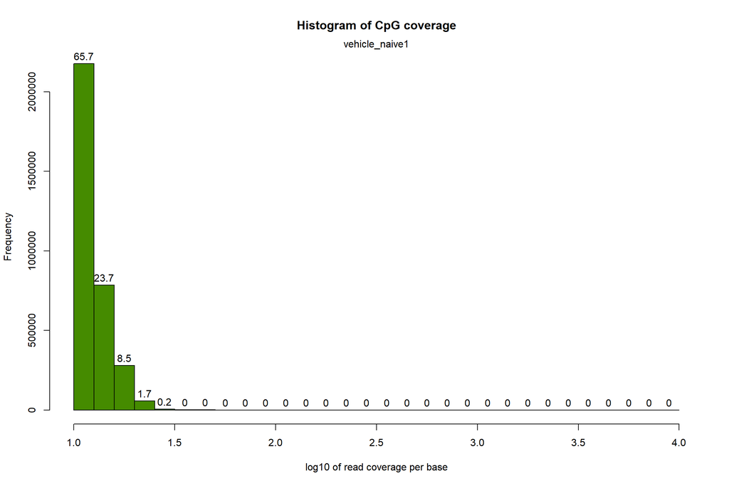

```r
naive_1 <- getCoverageStats(myobj[[1]],plot=TRUE,both.strands=FALSE)
```

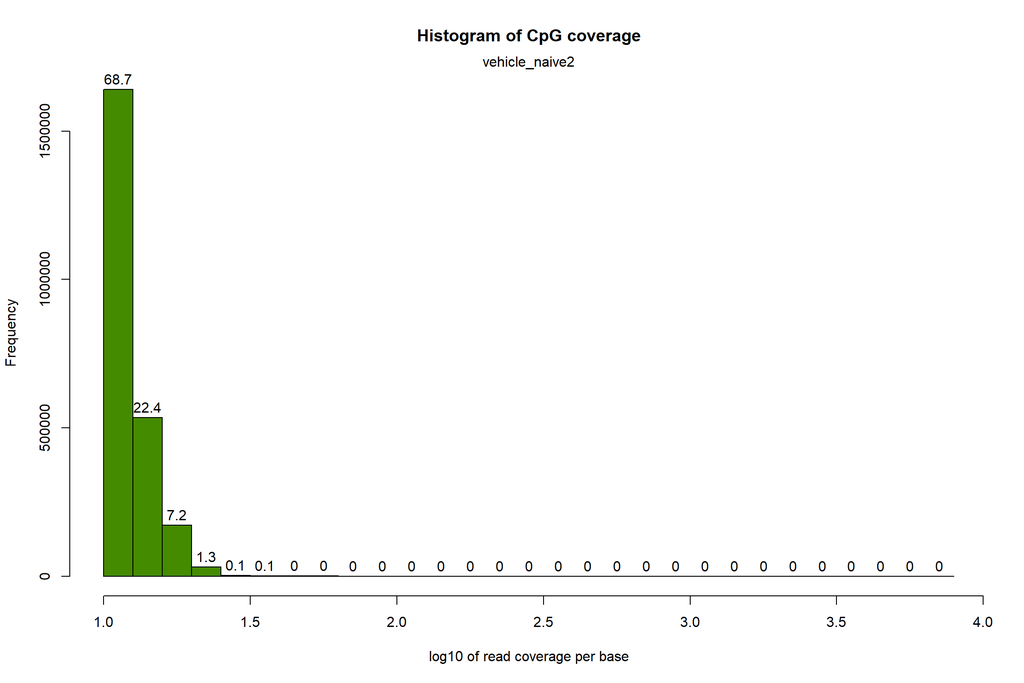

```r
naive_2 <- getCoverageStats(myobj[[2]],plot=TRUE,both.strands=FALSE)
```

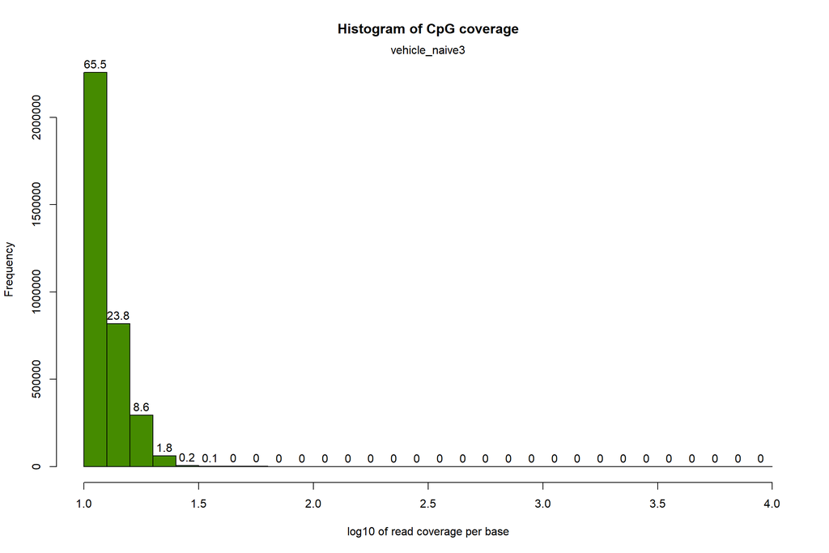

```r
naive_3 <- getCoverageStats(myobj[[3]],plot=TRUE,both.strands=FALSE)
```

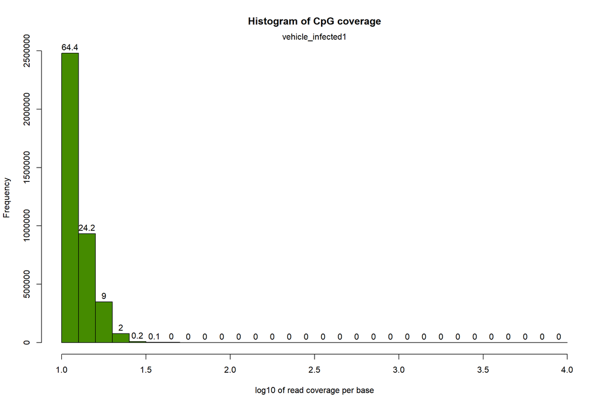

```r
infected_1 <- getCoverageStats(myobj[[4]],plot=TRUE,both.strands=FALSE)
```

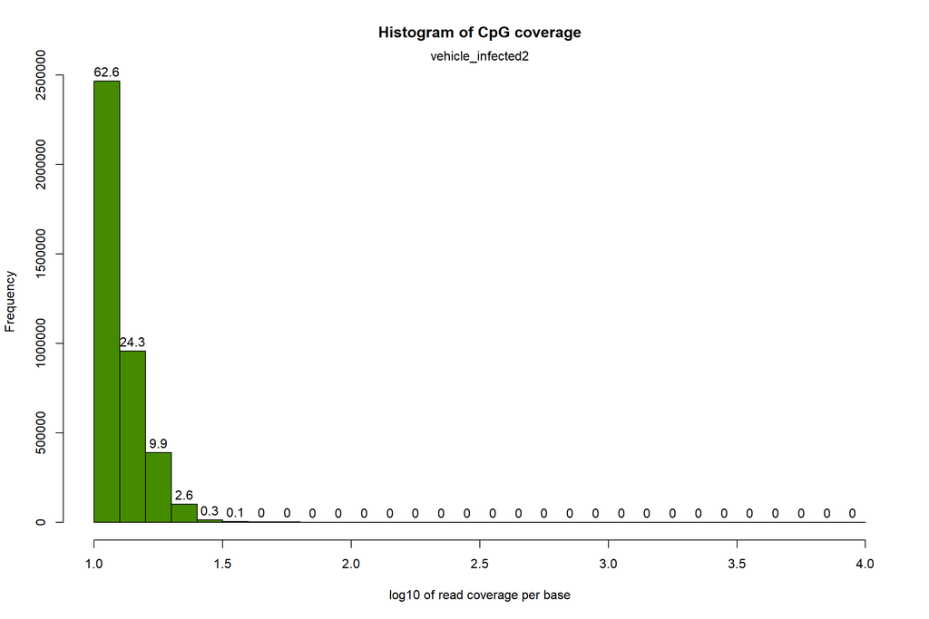

```r
infected_2 <- getCoverageStats(myobj[[5]],plot=TRUE,both.strands=FALSE)
```

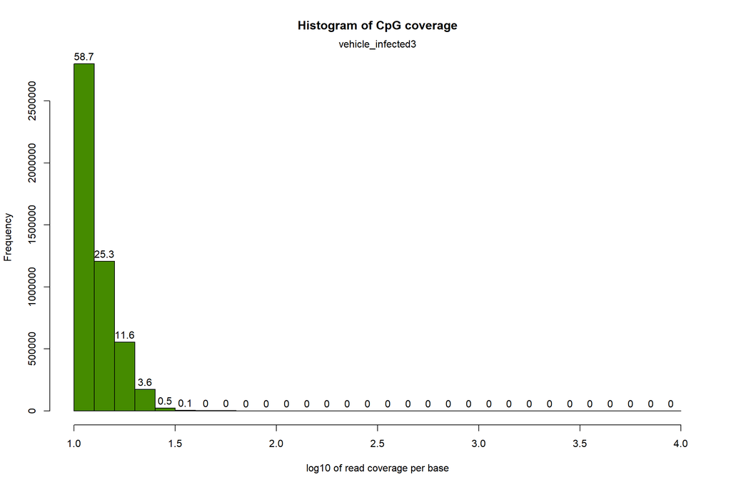

```r
infected_3 <- getCoverageStats(myobj[[6]],plot=TRUE,both.strands=FALSE)
```

filtering the data is not necessary because no signs of PCR bias are observed (features with very high coverage). But is strongly recommended by methylkit so....

```r
# filter out extreme coverage values (top 0.1%)
filtered <- filterByCoverage(myobj, hi.count = 99.9)

# normalize coverage to to avoid bias introduced by systematically more sequenced samples
normalized <- normalizeCoverage(filtered)
```

### merging samples

```r
# destrand parameter can be set to TRUE as we're working with base-pair resolution CpG methylation data. This increases coverage
meth=unite(normalized, destrand=TRUE)
```

```
## destranding...
```

```
## uniting...
```

```r
head(meth)
```

```
##          chr start   end strand coverage1 numCs1 numTs1 coverage2 numCs2 numTs2
## 1 GL456210.1   773   773      +        34     32      2        26     24      2
## 2 GL456210.1   779   779      +        36     36      0        28     24      4
## 3 GL456210.1  7360  7360      +        16     13      3        15     13      2
## 4 GL456210.1 17333 17333      +        20     10     10        11      9      2
## 5 GL456210.1 26873 26873      +        12     12      0        14     14      0
## 6 GL456210.1 33611 33611      +        34     24     10        29     21      8
##   coverage3 numCs3 numTs3 coverage4 numCs4 numTs4 coverage5 numCs5 numTs5
## 1        12     12      0        22     22      0        14     14      0
## 2        13     13      0        24     24      0        16     15      1
## 3        19     13      6        29     17     12        16     13      3
## 4        15      9      6        11      7      4        13      8      5
## 5        11     10      1        18     18      0        11     10      1
## 6        21     13      8        30     21      9        28     17     11
##   coverage6 numCs6 numTs6
## 1        14     14      0
## 2        13     11      2
## 3        19     14      5
## 4        27     19      8
## 5        10     10      0
## 6        31     24      7
```

get the sample correlation

```r
getCorrelation(meth,plot=F)
```

```
##                   vehicle_naive1 vehicle_naive2 vehicle_naive3
## vehicle_naive1         1.0000000      0.8918948      0.8959197
## vehicle_naive2         0.8918948      1.0000000      0.8957106
## vehicle_naive3         0.8959197      0.8957106      1.0000000
## vehicle_infected1      0.8900042      0.8923888      0.8952116
## vehicle_infected2      0.8916590      0.8929707      0.8954318
## vehicle_infected3      0.8965660      0.8973933      0.9013212
##                   vehicle_infected1 vehicle_infected2 vehicle_infected3
## vehicle_naive1            0.8900042         0.8916590         0.8965660
## vehicle_naive2            0.8923888         0.8929707         0.8973933
## vehicle_naive3            0.8952116         0.8954318         0.9013212
## vehicle_infected1         1.0000000         0.8950831         0.8993060
## vehicle_infected2         0.8950831         1.0000000         0.9004814
## vehicle_infected3         0.8993060         0.9004814         1.0000000
```

All samples have a very high correlation rate.

Cluster the samples samples

```r
clusterSamples(meth, dist="correlation", method="ward")
```

```
## The "ward" method has been renamed to "ward.D"; note new "ward.D2"
```

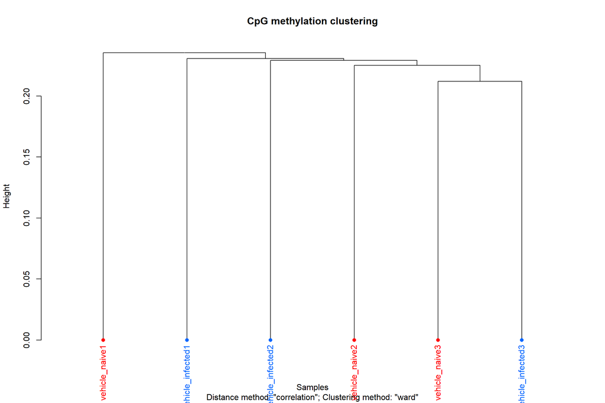

```
##
## Call:
## hclust(d = d, method = HCLUST.METHODS[hclust.method])
##
## Cluster method   : ward.D
## Distance         : pearson
## Number of objects: 6
```

PCA

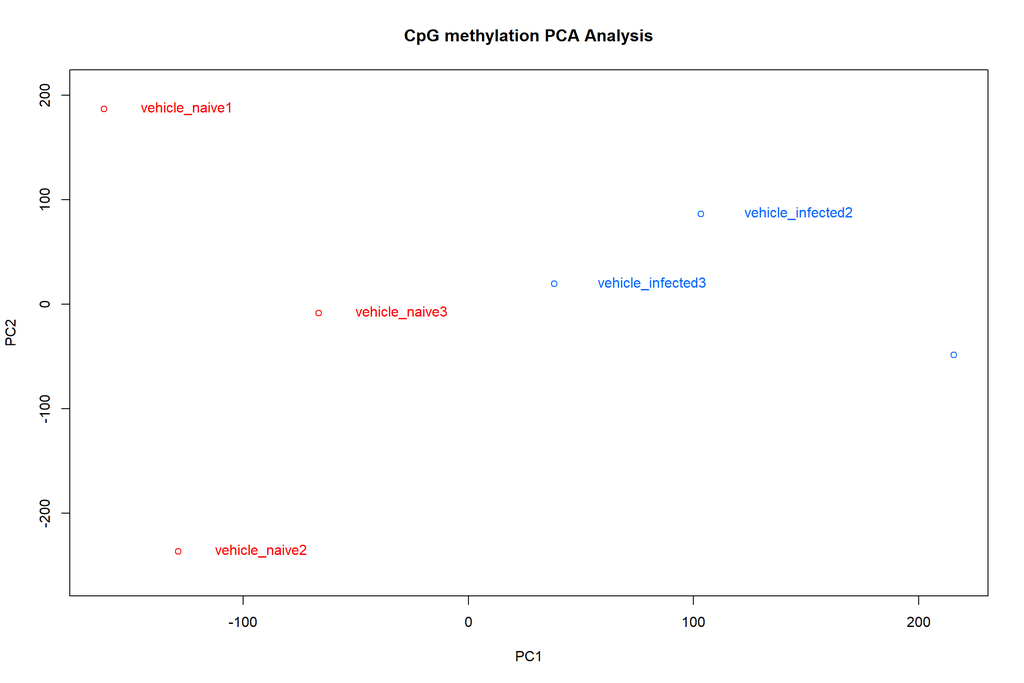

```r
PCASamples(meth)
```

get differentially methylated bases

```r
myDiff=calculateDiffMeth(meth)
```

```
## two groups detected:
##  will calculate methylation difference as the difference of
## treatment (group: 1) - control (group: 0)
```

```r
myDiff25p=getMethylDiff(myDiff,difference=50,qvalue=0.05)
diffMethPerChr(myDiff,plot=FALSE,qvalue.cutoff=0.05, meth.cutoff=25)
```

```
## $diffMeth.per.chr
##           chr number.of.hypermethylated percentage.of.hypermethylated
## 2        chr1                         3                   0.023485204
## 13       chr2                         2                   0.014286735
## 14       chr3                         5                   0.056605910
## 15       chr4                         0                   0.000000000
## 16       chr5                         1                   0.007189589
## 17       chr6                         1                   0.010610080
## 18       chr7                         2                   0.016335865
## 19       chr8                         3                   0.024135157
## 20       chr9                         1                   0.009399380
## 3       chr10                         2                   0.019892580
## 4       chr11                         0                   0.000000000
## 5       chr12                         0                   0.000000000
## 6       chr13                         2                   0.023482447
```

[output cut: 36 more lines]

```r
myDiff25p
```

```
##               chr    start      end strand       pvalue       qvalue meth.diff
## 823    JH584304.1    34304    34304      + 8.199773e-25 1.489274e-19  58.17783
## 2181         chr1 23116177 23116177      + 1.509287e-06 1.305345e-02 -50.82067
## 25320       chr11 12515663 12515663      + 3.913577e-06 2.328643e-02 -50.73359
## 54015       chr14 14346963 14346963      + 3.793240e-07 5.299560e-03 -51.04396
## 57803       chr14 63756321 63756321      + 2.402432e-07 3.636157e-03  52.82230
## 73359       chr16 67339031 67339031      + 1.342956e-05 3.752504e-02 -50.11583
## 85272       chr18 12517640 12517640      + 2.020320e-07 3.636157e-03 -53.55898
## 113429       chr3 57941935 57941935      + 5.898043e-17 5.356126e-12  81.43590
## 163682       chr7 79299862 79299862      + 1.501372e-07 3.636157e-03  51.22549
```

```r
Diffmeth <-calculateDiffMeth(meth, overdispersion="MN",test="Chisq")
```

```
## two groups detected:
##  will calculate methylation difference as the difference of
## treatment (group: 1) - control (group: 0)
```

```r
Diff25p=getMethylDiff(Diffmeth,difference=50,qvalue=0.05)
diffMethPerChr(Diffmeth,plot=FALSE,qvalue.cutoff=0.05, meth.cutoff=25)
```

```
## $diffMeth.per.chr
##    chr number.of.hypermethylated percentage.of.hypermethylated
## 1 chr3                         2                    0.02264236
## 2 chr4                         0                    0.00000000
##   number.of.hypomethylated percentage.of.hypomethylated
## 1                        0                  0.000000000
## 2                        1                  0.006873325
##
## $diffMeth.all
##   number.of.hypermethylated percentage.of.hypermethylated
## 1                         2                   0.001007998
##   number.of.hypomethylated percentage.of.hypomethylated
## 1                        1                 0.0005039992
```

There appear to be a very low number of differentially methylated positions between cells from mice infected with influenza and those that are not infected with influenza.

### annotating differentially methylated bps

```r
library(genomation)
# load the hgr18 bed file.
gene.obj=readTranscriptFeatures("C:/Users/tobia/Documents/AHAT/mm10_RefSeq.bed.gz")
```

```
## Reading the table...
```

```
## Calculating intron coordinates...
```

```
## Calculating exon coordinates...
```

```
## Calculating TSS coordinates...
```

```
## Calculating promoter coordinates...
```

```
## Outputting the final GRangesList...
```

```r
# annotate to promotors, exons, introns.
diffAnn=annotateWithGeneParts(as(myDiff25p,"GRanges"),gene.obj)
# get associated transcription start sites
getAssociationWithTSS(diffAnn)
```

```
##      target.row dist.to.feature   feature.name feature.strand
## 2654          2           -7812    XR_373275.2              +
## 446           3          -50704 XM_006514485.3              -
## 1756          4            -134 XM_006517940.1              +
## 3580          5          -13886    XR_383493.2              -
## 2992          6          106991    XR_876148.2              -
## 30            7           13434 XM_006525690.2              +
## 2433          8           -7173    XR_867305.2              +
## 5296          9             914    XR_882244.1              +
```

```r
# save features as vector
features <- c("no feature linked", getAssociationWithTSS(diffAnn)[[3]])
features
```

```
## [1] "no feature linked" "XR_373275.2"       "XM_006514485.3"
## [4] "XM_006517940.1"    "XR_383493.2"       "XR_876148.2"
## [7] "XM_006525690.2"    "XR_867305.2"       "XR_882244.1"
```

```r
dist_features <- c(NA, getAssociationWithTSS(diffAnn)[[2]])

summary <- as.data.frame(myDiff25p)
# add feature information to myDiff25p
summary$feature <- features
summary$dist.to.feature <- dist_features
summary
```

```
##               chr    start      end strand       pvalue       qvalue meth.diff
## 823    JH584304.1    34304    34304      + 8.199773e-25 1.489274e-19  58.17783
## 2181         chr1 23116177 23116177      + 1.509287e-06 1.305345e-02 -50.82067
## 25320       chr11 12515663 12515663      + 3.913577e-06 2.328643e-02 -50.73359
## 54015       chr14 14346963 14346963      + 3.793240e-07 5.299560e-03 -51.04396
## 57803       chr14 63756321 63756321      + 2.402432e-07 3.636157e-03  52.82230
## 73359       chr16 67339031 67339031      + 1.342956e-05 3.752504e-02 -50.11583
## 85272       chr18 12517640 12517640      + 2.020320e-07 3.636157e-03 -53.55898
## 113429       chr3 57941935 57941935      + 5.898043e-17 5.356126e-12  81.43590
## 163682       chr7 79299862 79299862      + 1.501372e-07 3.636157e-03  51.22549
##                  feature dist.to.feature
## 823    no feature linked              NA
## 2181         XR_373275.2           -7812
## 25320     XM_006514485.3          -50704
## 54015     XM_006517940.1            -134
## 57803        XR_383493.2          -13886
## 73359        XR_876148.2          106991
## 85272     XM_006525690.2           13434
## 113429       XR_867305.2           -7173
## 163682       XR_882244.1             914
```

```r
diffAnn@members
```

```
##       prom exon intron
##  [1,]    0    0      0
##  [2,]    0    0      0
##  [3,]    0    0      0
##  [4,]    1    1      1
##  [5,]    0    0      1
##  [6,]    0    0      1
##  [7,]    0    0      1
##  [8,]    0    0      0
##  [9,]    1    1      1
```

```r
promoters=regionCounts(normalized,gene.obj$promoters)

head(promoters[[1]])
```

```
##    chr   start     end strand coverage numCs numTs
## 1 chr1 3360551 3362551      +       11    10     1
## 2 chr1 3670498 3672498      -      285    16   270
## 3 chr1 3671278 3673278      -      160    15   146
## 4 chr1 4232728 4234728      -       25    17     8
## 5 chr1 4242365 4244365      -       11     8     3
## 6 chr1 4359314 4361314      -       26    21     5
```

```r
getTargetAnnotationStats(diffAnn,percentage=TRUE,precedence=TRUE)
```

```
##   promoter       exon     intron intergenic
##      22.22       0.00      33.33      44.44
```

same for more stringent

```r
# annotate to promotors, exons, introns.
diffAnn_str=annotateWithGeneParts(as(Diff25p,"GRanges"),gene.obj)

# get associated transcription start sites
getAssociationWithTSS(diffAnn_str)
```

```
##      target.row dist.to.feature feature.name feature.strand
## 2433          1           -7173  XR_867305.2              +
```

```r
# save features as vector
features <- c(getAssociationWithTSS(diffAnn_str)[[3]])

dist_features <- c(getAssociationWithTSS(diffAnn_str)[[2]])

summary <- as.data.frame(Diff25p)
# add feature information to myDiff25p
summary$feature <- features
summary$dist.to.feature <- dist_features
summary
```

```
##         chr    start      end strand       pvalue       qvalue meth.diff
## 113429 chr3 57941935 57941935      + 5.898043e-17 1.117464e-11   81.4359
##            feature dist.to.feature
## 113429 XR_867305.2           -7173
```

```r
diffAnn_str@members
```

```
##      prom exon intron
## [1,]    0    0      0
```

```r
getTargetAnnotationStats(diffAnn_str,percentage=TRUE,precedence=TRUE)
```

```
##   promoter       exon     intron intergenic
##          0          0          0        100
```